# Getting Started In Data Science

This was a solo project by Alexander Glatfelter

Hello there!  
This is a tutorial for absolute beginners on how to get started with a Data Science project. In this we'll focus on the five major steps of Data Science:

- Data Collection - How to obtain raw data
- Data Cleaning - How to change raw data into usable data
- Exploratory Analysis & Visualization - How we look at the data
- Hypothesis Testing and Modeling - How we analyze the data fully
- Drawing Conclusions - What we will learn from the previous steps

Data Science may seem like an imposing thing but in the end, Data Science is about trying to answer a question you have.

If you think about it, when you want an anwser to a question, you would follow the same steps.

- You would research your topic
- Gather everything you think is important and organize it
- Synthesize ideas from that data
- Then draw your conclusion from the whole.

Data Science is the same, the only difference is the methods and algorithms of Data Science let you do this with massive amounts of data.

There's this nice thing about Data Science, a lot of the tools are available to you for free. This tutorial was created in a [Jupyter Notebook](https://jupyter.org/install), and all of the libraries we'll use can be downloaded with the commands in this tutorial. The only thing you'll need is a computer, the internet, and a little bit of time.

Whenever I use a method or a function in this tutorial, I'll frame it like `this`, these will be links to it's documentation, so that if you're following along and have an issue, you can click on it to find out a little more about it.

No Data Science experience is necessary to follow this tutorial, and we'll go step by step through some easily accessable example data. That way, you can follow along if you want. The only thing I'll assume is that you know basic programming concepts and have a vague familiarity with Python.

We'll be using easily accessable data for this tutorial, and all the data will have the theme of Football.

We'll get our first batch of data from a standard website. While there's [numerous](https://www.kaggle.com/) [websites](https://data.gov/) and even a [Google Dataset Search](https://datasetsearch.research.google.com/) to get pre-existing sets of data from, I'd like to show you how to get that data in the wild.

There will be nothing pre-processed or collected for us in the beginning of this tutorial, we're going to pick the proverbial apple from the tree ourselves.

For this first part, we're going to use this website: https://umterps.com/sports/football/stats/2021

This is the University of Maryland's 2021 Statistics Page. If you take a quick look, there's no "download dataset" or anything like that. It's just a simple webpage like any other with graphics, tables, ads, and links to other pages.

## Data Collection

First we'll need to install something to help process HTML format, which is what the raw data of the websites we'll be recieving.  
For this, we'll install [`lxml`](https://lxml.de/installation.html) using the [`pip`](https://pypi.org/project/pip/) command. Like the reponse says, you may need to restart your notebook kernel in order to finish the installation.

After that, we'll [`import`](https://docs.python.org/3/reference/import.html) [`requests`](https://pypi.org/project/requests/), which is a library that will let us gather data directly from websites with no struggle.

```python
## Note: This isn't required for any of our data science, sadly
#        I was unable to embed images into this document without
#        importing this function.  Please ignore this and any calls
#        for Image(filename="img/some name here")
from IPython.display import Image
```

```python
%pip install lxml
import requests
```

So we know the data we want is online, so all we need to do is just download the information from the page and we'll be set! ....Right?

Let's download the Terrapin stats for 2021, then we can look through it and find the information we want. We'll start by using the [`requests`](https://pypi.org/project/requests/) library to `get` the information from the URL.  
This technique is called **scraping** and it's basically asking for all of the webpage's information.

We already have the URL to get our info: https://umterps.com/sports/football/stats/2021

```python
url = "https://umterps.com/sports/football/stats/2021"
UMD_2021 = requests.get(url)
```

Alright! We've **scraped** the webpage using [`requests`](https://pypi.org/project/requests/) and it's returned the webpage as a result! All we need to do is print it out using print() and look at the information....and..uhmm...

```
print(UMD_2021.text)
```

<sub>The text is huge, so here's a picture excerpt of the file:</sub>

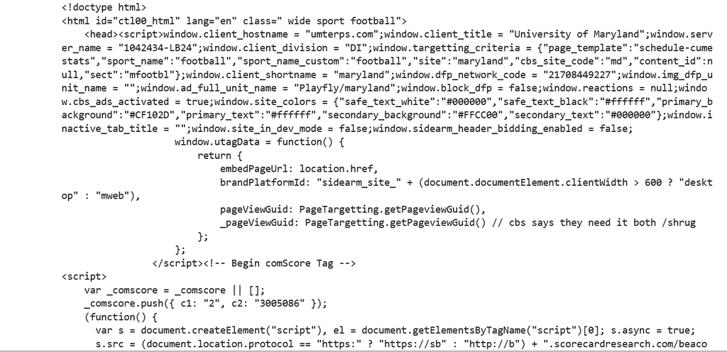

```python
Image(filename="img/LongText0.png",alt="At first glance, not bad")
```

....*hmmm*.

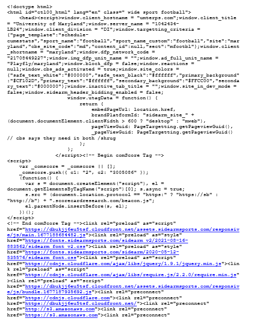

```python
Image(filename="LongText1.png",alt="It's...big")
```

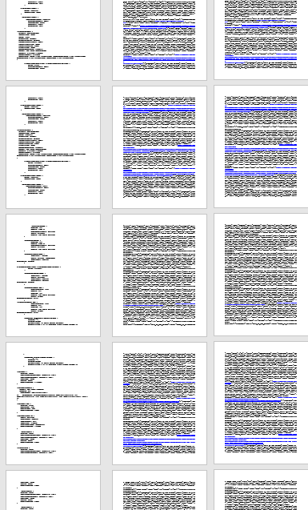

```python
Image(filename="LongtextCombined.png", alt="Yikes, it's 386 pages long")
```

Ok yeah, this clearly isn't going to work as is.

And yes, you *could* look through **386** pages of 10-font HTML code, carefully copy down all the information, and then begin figuring out what you needed from it, but there's a much, MUCH, better better way.

## Data Cleaning

Now we'll introduce the concept of **Data Cleaning** which basically means transforming raw data into something useful. The nice thing is that there are already tools available to handle this task.

We're going to use a library called [`beautiful soup`](https://www.crummy.com/software/BeautifulSoup/), to help us process the block of webpage HTML.

This will clean up the sprawling HTML code and make it nice(*er*) and neat(*er*) to read:

```python
from bs4 import BeautifulSoup
#This will read the raw data of the website, and parse it as HTML!
soup = BeautifulSoup(UMD_2021.content, 'html.parser')
#Then we can use it's prettify() in order to space it out and make it easier to read.
```

Let's see a brief section of what it would look like if we ran [`.prettify()`](https://www.crummy.com/software/BeautifulSoup/bs4/doc/#pretty-printing) on the massive html text block.

Normally it would start a new line for each \n, but it's acting a little weird on my system. But we can still see how the page is supposed to be laid out now. Each \n represents the end of one line, and the beginning of another. If we take a look:

```
soup.prettify()
```

<sub>this is another large block of text, so I'll show you a picture of some of it</sub>

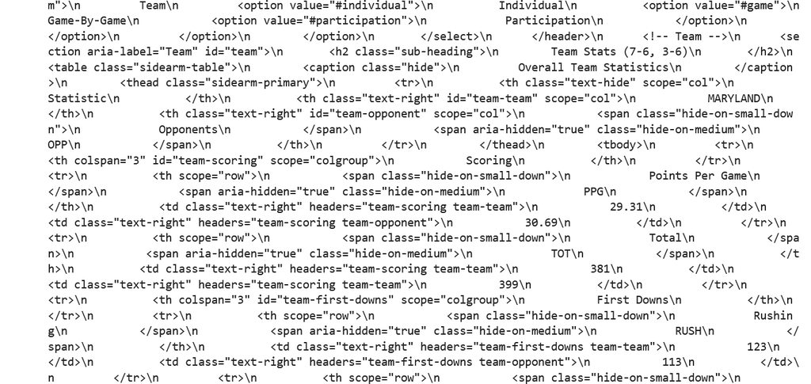

```python
Image(filename="SoupPret.png", alt="It's....better")
```

Ok, so beautiful soup used an HTML parser in order to convert that **HUMONGOUS** block of text into a merely HUGE organized block of text. This was still a useful step, since we can still see where the data is in there.

For example about halfway through you can see "team-scoring team-team" followed by "29.31". The data is there we just need to **transform** it into a more human-accessable form.

So, the next step is to further clean up that data. We're going to keep using [`beautiful soup`](https://www.crummy.com/software/BeautifulSoup/) in order to do so. This next step, we're going to call the [`soup.find`](https://www.crummy.com/software/BeautifulSoup/bs4/doc/#find) method of the soup object we created up above.  
Now that object was parsed as *html* which means it's now in an HTML format, that means if we look for 'table', beautiful soup will parse the main table into a string.

```python
html_str_table = soup.find('table')
## Now let's print it:
#print(html_str_table)
# Another big file, you know the drill:
```

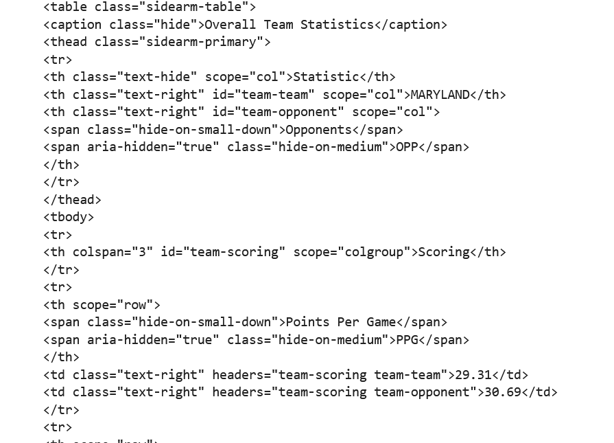

```python
Image(filename="Tables.png", alt="MUCH NICER...we can actually use this!")
```

Now that looks 1000% better than the 386 page block of text. We can actually see what the various tables on the website are.

If you're familiar with HTML code, you have a rough idea of what that means up above, however for a lot of people, that's not super clear. Let's take a look at the website we're scraping from.

[figure not shown]

```python
Image(filename="Web2021.png" )
```

Ok, we can clearly see similarites between the two. Near the bottom of our html_str_table we see "Points Per Game", and the values 29.31 and 30.69. If you look at the picture of the website, you can see the same thing at the top of the chart. This confirms we've got the data.

So now the next part, lets get this data into a table we can use to process and measure it. A good way to do this is through [`Pandas`](https://pandas.pydata.org/docs/index.html), which is a wonderfully powerful data science processing library.

We'll import pandas through the statement `import pandas as pd` which will let us refer to it in a shorthand as 'pd'.

```python
import pandas as pd
```

Now we'll use [`pandas.read_html`](https://pandas.pydata.org/docs/reference/api/pandas.read_html.html) method in order to convert all of those table formats into **dataframes** with the information in them.

**Dataframes** are 2-D tables that are easily modified and have a wide variety of functions that pandas provides to work with them. By importing these text based tables to pandas, we'll get our information in an easier format.  
So lets convert it, and then look at the first index of our dataframe of hmtl-tables:

```python
table = pd.read_html(str(soup))
dataframe = table[0]
## There's a lot of data, let's limit it to 20 to make it simple to read.
## Don't worry though, all the rest of the data is still there.
## .head(N) give's you the first N values
dataframe.head(20)
```

|  | Statistic | MARYLAND | Opponents OPP |
| --- | --- | --- | --- |
| 0 | Scoring | Scoring | Scoring |
| 1 | Points Per Game PPG | 29.31 | 30.69 |
| 2 | Total TOT | 381 | 399 |
| 3 | First Downs | First Downs | First Downs |
| 4 | Rushing RUSH | 123 | 113 |
| 5 | Passing PASS | 166 | 130 |
| 6 | Penalty PEN | 17 | 30 |
| 7 | Total TOT | 306 | 273 |
| 8 | Rushing | Rushing | Rushing |
| 9 | Yards Gained YDS | 2141 | 2328 |
| 10 | Yards Lost YDL | 367 | 316 |
| 11 | Attempts ATT | 439 | 500 |
| 12 | Average Per Attempt AVG/ATT | 4.0 | 4.0 |
| 13 | Avg. Per Game AVG/G | 136.5 | 154.8 |
| 14 | Touchdowns TDS | 20 | 24 |
| 15 | Total TOT | 1774 | 2012 |
| 16 | Passing | Passing | Passing |
| 17 | Att-Comp-Int ATT-CMP-INT | 489-339-12 | 410-241-6 |
| 18 | Avg. Per Attempt AVG/ATT | 8.10 | 7.91 |
| 19 | Avg. Per Game AVG/G | 304.62 | 249.54 |

Cool, it looks like the first table is the whole "TEAM" table on the webpage. It's not the most **tidy** of datasets, there's a whole row taken for each category label ("Passing" for example). But we can fix that as we go on. The next, and very important question: does it contain the other tables?

Let's check another index value for table[] to see

```python
dataframe = table[1]
dataframe.head(20)
```

|  | # | Player | GP | ATT | Gain | Loss | Net | AVG | TD | Long | AVG/G | Bio Link |
| --- | --- | --- | --- | --- | --- | --- | --- | --- | --- | --- | --- | --- |
| 0 | 8.0 | Fleet-Davis, Tayon 8 Fleet-Davis, Tayon | 13 | 128 | 744 | 23 | 721 | 5.6 | 8 | 53 | 55.46 | View Bio |
| 1 | 23.0 | McDonald, Colby 23 McDonald, Colby | 8 | 60 | 335 | 10 | 325 | 5.4 | 2 | 41 | 40.63 | View Bio |
| 2 | 29.0 | Faamatau, Challen 29 Faamatau, Challen | 9 | 56 | 251 | 16 | 235 | 4.2 | 3 | 30 | 26.11 | View Bio |
| 3 | 13.0 | Boone, Peny 13 Boone, Peny | 10 | 39 | 189 | 17 | 172 | 4.4 | 2 | 28 | 17.20 | View Bio |
| 4 | NaN | Jacobs, Isaiah Jacobs, Isaiah | 5 | 28 | 117 | 1 | 116 | 4.1 | 0 | 11 | 23.20 | NaN |
| 5 | 3.0 | Tagovailoa, Taulia 3 Tagovailoa, Taulia | 13 | 80 | 350 | 269 | 81 | 1.0 | 2 | 45 | 6.23 | View Bio |
| 6 | NaN | Littleton, Antwaine Littleton, Antwaine | 2 | 15 | 77 | 3 | 74 | 4.9 | 1 | 11 | 37.00 | NaN |
| 7 | 24.0 | Hemby, Roman 24 Hemby, Roman | 3 | 17 | 73 | 2 | 71 | 4.2 | 2 | 11 | 23.67 | View Bio |
| 8 | 5.0 | Jarrett, Rakim 5 Jarrett, Rakim | 13 | 4 | 5 | 3 | 2 | 0.5 | 0 | 2 | 0.15 | View Bio |
| 9 | 54.0 | Anderson, Spencer 54 Anderson, Spencer | 13 | 0 | 0 | 0 | 0 | 0.0 | 0 | 0 | 0.00 | View Bio |
| 10 | 21.0 | Jones, Darryl 21 Jones, Darryl | 13 | 1 | 0 | 3 | -3 | -3.0 | 0 | 0 | -0.23 | View Bio |
| 11 | 15.0 | Cobbs, Brian 15 Cobbs, Brian | 13 | 1 | 0 | 4 | -4 | -4.0 | 0 | 0 | -0.31 | View Bio |
| 12 | NaN | Team Team | 13 | 10 | 0 | 16 | -16 | -1.6 | 0 | 0 | -1.23 | NaN |
| 13 | NaN | Total | 13 | 439 | 2141 | 367 | 1774 | 4.0 | 20 | 53 | 136.46 | NaN |
| 14 | NaN | Opponents | 13 | 500 | 2328 | 316 | 2012 | 4.0 | 24 | 66 | 154.77 | NaN |

A quick double-check with the website shows this is the "Individual" "Offense" "Rushing" table.

[figure not shown]

```python
Image(filename="2021WebRushing.png" )
```

```
            (Also just so you know, this project was not sponsored by Myrtle Beach)
```

While we'll double check, it can be safe to say that we've gotten all the data on this website, now we just need to **Tidy** the data.

Roughly speaking, **Tidy Data** is the concept that all data should be organized in easily processable rows. The idea encompasses a lot of important concepts, so [reading up on it](http://vita.had.co.nz/papers/tidy-data.pdf) should be something you should look into if you're interested in data science.

But I'll give you the most important basics:

- Each observation forms a Row (Horizontal)
- Each measurement (aka variable or feature) is a column
- Each type of observation has its own table

<sub>Note: *I highly recommend reading the link just above, as it explains the concepts and ideals in more depth.*</sub>

So what's the next step? Cleaning and **Tidying** that data! This is what I would consider one of the *most important* steps in Data Science, and probably the longest step in general.

So here's what we'll do, we'll go through each table, fix any missing data we find, get rid of any unecessary data, reshape the tables into something more easily usable, and make sure all the measurement units line up. Then we'll do that for all of the other years that the data is available.

If you're thinking "*that's a good bit of work*" you're right. So we'll make functions to process the data rather than type all the commands by hand each time. We'll work through the first table to see what we need to do.

First, lets start with the Overall Team info. That was table #0:

```python
UMD2021_Team = table[0]
UMD2021_Team
```

|  | Statistic | MARYLAND | Opponents OPP |
| --- | --- | --- | --- |
| 0 | Scoring | Scoring | Scoring |
| 1 | Points Per Game PPG | 29.31 | 30.69 |
| 2 | Total TOT | 381 | 399 |
| 3 | First Downs | First Downs | First Downs |
| 4 | Rushing RUSH | 123 | 113 |
| 5 | Passing PASS | 166 | 130 |
| 6 | Penalty PEN | 17 | 30 |
| 7 | Total TOT | 306 | 273 |
| 8 | Rushing | Rushing | Rushing |
| 9 | Yards Gained YDS | 2141 | 2328 |
| 10 | Yards Lost YDL | 367 | 316 |
| 11 | Attempts ATT | 439 | 500 |
| 12 | Average Per Attempt AVG/ATT | 4.0 | 4.0 |
| 13 | Avg. Per Game AVG/G | 136.5 | 154.8 |
| 14 | Touchdowns TDS | 20 | 24 |
| 15 | Total TOT | 1774 | 2012 |
| 16 | Passing | Passing | Passing |
| 17 | Att-Comp-Int ATT-CMP-INT | 489-339-12 | 410-241-6 |
| 18 | Avg. Per Attempt AVG/ATT | 8.10 | 7.91 |
| 19 | Avg. Per Game AVG/G | 304.62 | 249.54 |
| 20 | Touchdowns TDS | 27 | 22 |
| 21 | Total TOT | 3960 | 3244 |
| 22 | Total Offense | Total Offense | Total Offense |
| 23 | Total Plays TOT | 928 | 910 |
| 24 | Avg. Per Play AVG/P | 6.2 | 5.8 |
| 25 | Avg. Per Game AVG/G | 441.1 | 404.3 |
| 26 | Total Yards TOT YDS | 5734 | 5256 |
| 27 | Touchdowns TDS | 49 | 50 |
| 28 | Returns | Returns | Returns |
| 29 | Kickoff: Average KO: AVG | 17.04 | 26.02 |
| 30 | Kickoff: Total KO: TOT | 27-460 | 46-1197 |
| 31 | Punt: Average P: AVG | 7.96 | 6.36 |
| 32 | Punt: Total P: TOT | 23-183 | 22-140 |
| 33 | INT: Average INT: AVG | 9.00 | 26.42 |
| 34 | INT: Total INT: TOT | 6-54 | 12-317 |
| 35 | Kicking | Kicking | Kicking |
| 36 | Punt: Avg. Yards Per Game P: AVG/G | 43.25 | 39.92 |
| 37 | Punt: Net Average P: Net AVG | 38.51 | 36.20 |
| 38 | Punt: Total Yards P: YDS | 59-2552 | 60-2395 |
| 39 | FG: Good-Attempts FG: FGM-FGA | 14-21 | 16-21 |
| 40 | Onside Kicks Onside K | 0-1 | 0-2 |
| 41 | Penalties | Penalties | Penalties |
| 42 | Avg. Per Game (YDS) AVG/G | 57.15 | 47.46 |
| 43 | Total-Yards TOT/YDS | 88-743 | 73-617 |
| 44 | Time Of Possession | Time Of Possession | Time Of Possession |
| 45 | Avg. Per Game AVG/G | 28:38 | 30:53 |
| 46 | Total TOT | 06:12:11 | 06:41:32 |
| 47 | Miscellaneous | Miscellaneous | Miscellaneous |
| 48 | 3rd Down Conversions 3rd % | 65-170 (38.24 %) | 74-183 (40.44 %) |
| 49 | 4th Down Conversions 4th % | 11-22 (50.00 %) | 11-25 (44.00 %) |
| 50 | Fumbles-Lost FUM-Lost | 14-6 | 12-5 |
| 51 | Sacks-Yards Lost SCK YDS | 31-229 | 26-243 |
| 52 | PAT: Good-Attempts PAT | 41-46 | 47-48 |
| 53 | Misc. Yards MISC YDS | 6 | 85 |
| 54 | Red Zone: Attempts-Scores RZ: ATT-Score | 45-60 | 45-56 |
| 55 | Red Zone: Touchdowns RZ: TDS | 33-60 | 32-56 |

Ok, using the idea of **tidy** data, we're going to transform this table into a more organized dataset.  
We could consider this a "single" observation. So we could consider this table the "Average Team Statistics For the Year 2021 at University Of Maryland, College Park."  
That means all of this information is **one** observation on the "Average Team Statistics for UMD Football." We need to transform all of this data into a single row, so that we could compare the various year's statistics. We also should move the Opponent data to its own dataframe by year.

So we'll start by [`transpose`](https://pandas.pydata.org/docs/reference/api/pandas.DataFrame.transpose.html)-ing the data, this will make 1 "entry" for our year, 2021

**Note:** We're going to assign the transpose to a new variable. This is helpful because it prevents you from modifiying your original data. That way, if you need to approach from another angle, you can just assign the original data to a new variable and try again.

```python
UMD2021_Team_Avg = UMD2021_Team.transpose()
UMD2021_Team_Avg
```

|  | 0 | 1 | 2 | 3 | 4 | 5 | 6 | 7 | 8 | 9 | ... | 46 | 47 | 48 | 49 | 50 | 51 | 52 | 53 | 54 | 55 |
| --- | --- | --- | --- | --- | --- | --- | --- | --- | --- | --- | --- | --- | --- | --- | --- | --- | --- | --- | --- | --- | --- |
| Statistic | Scoring | Points Per Game PPG | Total TOT | First Downs | Rushing RUSH | Passing PASS | Penalty PEN | Total TOT | Rushing | Yards Gained YDS | ... | Total TOT | Miscellaneous | 3rd Down Conversions 3rd % | 4th Down Conversions 4th % | Fumbles-Lost FUM-Lost | Sacks-Yards Lost SCK YDS | PAT: Good-Attempts PAT | Misc. Yards MISC YDS | Red Zone: Attempts-Scores RZ: ATT-Score | Red Zone: Touchdowns RZ: TDS |
| MARYLAND | Scoring | 29.31 | 381 | First Downs | 123 | 166 | 17 | 306 | Rushing | 2141 | ... | 06:12:11 | Miscellaneous | 65-170 (38.24 %) | 11-22 (50.00 %) | 14-6 | 31-229 | 41-46 | 6 | 45-60 | 33-60 |
| Opponents OPP | Scoring | 30.69 | 399 | First Downs | 113 | 130 | 30 | 273 | Rushing | 2328 | ... | 06:41:32 | Miscellaneous | 74-183 (40.44 %) | 11-25 (44.00 %) | 12-5 | 26-243 | 47-48 | 85 | 45-56 | 32-56 |

3 rows × 56 columns

Now we'll start making changes to the table.

First: We'll copy the first row (*Statistic*) and make it the column headers  
Second: We'll [`drop`](https://pandas.pydata.org/docs/reference/api/pandas.DataFrame.drop.html) that row because we won't need it anymore

```python
## Set our column header = our row located at 0 (first one)
UMD2021_Team_Avg.columns = UMD2021_Team_Avg.iloc[0]
## Drop the row at 0, since we don't need it anymore
# Here we equate the current data frame to the new, modified one.
# However we could also do this "inplace" which would change the dataframe
# at it's source.  The code to do that would be:
# UMD2021_Team_Avg.drop(['Statistic'], axis = 0, inplace= True)
UMD2021_Team_Avg = UMD2021_Team_Avg.drop(['Statistic'], axis = 0)
UMD2021_Team_Avg
```

| Statistic | Scoring | Points Per Game PPG | Total TOT | First Downs | Rushing RUSH | Passing PASS | Penalty PEN | Total TOT | Rushing | Yards Gained YDS | ... | Total TOT | Miscellaneous | 3rd Down Conversions 3rd % | 4th Down Conversions 4th % | Fumbles-Lost FUM-Lost | Sacks-Yards Lost SCK YDS | PAT: Good-Attempts PAT | Misc. Yards MISC YDS | Red Zone: Attempts-Scores RZ: ATT-Score | Red Zone: Touchdowns RZ: TDS |
| --- | --- | --- | --- | --- | --- | --- | --- | --- | --- | --- | --- | --- | --- | --- | --- | --- | --- | --- | --- | --- | --- |
| MARYLAND | Scoring | 29.31 | 381 | First Downs | 123 | 166 | 17 | 306 | Rushing | 2141 | ... | 06:12:11 | Miscellaneous | 65-170 (38.24 %) | 11-22 (50.00 %) | 14-6 | 31-229 | 41-46 | 6 | 45-60 | 33-60 |
| Opponents OPP | Scoring | 30.69 | 399 | First Downs | 113 | 130 | 30 | 273 | Rushing | 2328 | ... | 06:41:32 | Miscellaneous | 74-183 (40.44 %) | 11-25 (44.00 %) | 12-5 | 26-243 | 47-48 | 85 | 45-56 | 32-56 |

2 rows × 56 columns

There, now the data looks more like an actual table we can use. However we still have some odd columns, "Scoring" for example. We'll need to remove those as well. First let's take a look at what all of our columns are in a list, using python's [`list()`](https://docs.python.org/3/library/stdtypes.html?#list):

```python
list(UMD2021_Team_Avg)
```

```
['Scoring',
 'Points Per Game PPG',
 'Total TOT',
 'First Downs',
 'Rushing RUSH',
 'Passing PASS',
 'Penalty PEN',
 'Total TOT',
 'Rushing',
 'Yards Gained YDS',
 'Yards Lost YDL',
 'Attempts ATT',
 'Average Per Attempt AVG/ATT',
 'Avg. Per Game AVG/G',
 'Touchdowns TDS',
 'Total TOT',
 'Passing',
 'Att-Comp-Int ATT-CMP-INT',
 'Avg. Per Attempt AVG/ATT',
 'Avg. Per Game AVG/G',
 'Touchdowns TDS',
 'Total TOT',
 'Total Offense',
 'Total Plays TOT',
 'Avg. Per Play AVG/P',
 'Avg. Per Game AVG/G',
 'Total Yards TOT YDS',
 'Touchdowns TDS',
 'Returns',
 'Kickoff: Average KO: AVG',
 'Kickoff: Total KO: TOT',
 'Punt: Average P: AVG',
 'Punt: Total P: TOT',
 'INT: Average INT: AVG',
 'INT: Total INT: TOT',
 'Kicking',
 'Punt: Avg. Yards Per Game P: AVG/G',
 'Punt: Net Average P: Net AVG',
 'Punt: Total Yards P: YDS',
 'FG: Good-Attempts FG: FGM-FGA',
 'Onside Kicks Onside K',
 'Penalties',
 'Avg. Per Game (YDS) AVG/G',
 'Total-Yards TOT/YDS',
 'Time Of Possession',
 'Avg. Per Game AVG/G',
 'Total TOT',
 'Miscellaneous',
 '3rd Down Conversions 3rd %',
 '4th Down Conversions 4th %',
 'Fumbles-Lost FUM-Lost',
 'Sacks-Yards Lost SCK YDS',
 'PAT: Good-Attempts PAT',
 'Misc. Yards MISC YDS',
 'Red Zone: Attempts-Scores RZ: ATT-Score',
 'Red Zone: Touchdowns RZ: TDS']
```

Ok, there's going to be some complications here. If you noticed, we have *multiple* "Avg. Per Game", and each one represents a different feature of the data. We can't just drop these out without impacting our dataset, and there's multiple instances of this happening ("Total TOT", etc)

So we'll go step by step through the headers and remove ([`drop`](https://pandas.pydata.org/docs/reference/api/pandas.DataFrame.drop.html)) the unnesscessary ones, and then we would usually [`rename`](https://pandas.pydata.org/docs/reference/api/pandas.DataFrame.rename.html) the identical ones to a more understandable name. However this won't quite work in this case. Let me show you why.

Here's the original dataframe:

```python
UMD2021_Team_Avg
```

| Statistic | Scoring | Points Per Game PPG | Total TOT | First Downs | Rushing RUSH | Passing PASS | Penalty PEN | Total TOT | Rushing | Yards Gained YDS | ... | Total TOT | Miscellaneous | 3rd Down Conversions 3rd % | 4th Down Conversions 4th % | Fumbles-Lost FUM-Lost | Sacks-Yards Lost SCK YDS | PAT: Good-Attempts PAT | Misc. Yards MISC YDS | Red Zone: Attempts-Scores RZ: ATT-Score | Red Zone: Touchdowns RZ: TDS |
| --- | --- | --- | --- | --- | --- | --- | --- | --- | --- | --- | --- | --- | --- | --- | --- | --- | --- | --- | --- | --- | --- |
| MARYLAND | Scoring | 29.31 | 381 | First Downs | 123 | 166 | 17 | 306 | Rushing | 2141 | ... | 06:12:11 | Miscellaneous | 65-170 (38.24 %) | 11-22 (50.00 %) | 14-6 | 31-229 | 41-46 | 6 | 45-60 | 33-60 |
| Opponents OPP | Scoring | 30.69 | 399 | First Downs | 113 | 130 | 30 | 273 | Rushing | 2328 | ... | 06:41:32 | Miscellaneous | 74-183 (40.44 %) | 11-25 (44.00 %) | 12-5 | 26-243 | 47-48 | 85 | 45-56 | 32-56 |

2 rows × 56 columns

And here's the dataframe after we use [`rename`](https://pandas.pydata.org/docs/reference/api/pandas.DataFrame.rename.html):

```python
UMD2021_Team_Avg.rename(columns={"Total TOT":"Total Scored"})
```

| Statistic | Scoring | Points Per Game PPG | Total Scored | First Downs | Rushing RUSH | Passing PASS | Penalty PEN | Total Scored | Rushing | Yards Gained YDS | ... | Total Scored | Miscellaneous | 3rd Down Conversions 3rd % | 4th Down Conversions 4th % | Fumbles-Lost FUM-Lost | Sacks-Yards Lost SCK YDS | PAT: Good-Attempts PAT | Misc. Yards MISC YDS | Red Zone: Attempts-Scores RZ: ATT-Score | Red Zone: Touchdowns RZ: TDS |
| --- | --- | --- | --- | --- | --- | --- | --- | --- | --- | --- | --- | --- | --- | --- | --- | --- | --- | --- | --- | --- | --- |
| MARYLAND | Scoring | 29.31 | 381 | First Downs | 123 | 166 | 17 | 306 | Rushing | 2141 | ... | 06:12:11 | Miscellaneous | 65-170 (38.24 %) | 11-22 (50.00 %) | 14-6 | 31-229 | 41-46 | 6 | 45-60 | 33-60 |
| Opponents OPP | Scoring | 30.69 | 399 | First Downs | 113 | 130 | 30 | 273 | Rushing | 2328 | ... | 06:41:32 | Miscellaneous | 74-183 (40.44 %) | 11-25 (44.00 %) | 12-5 | 26-243 | 47-48 | 85 | 45-56 | 32-56 |

2 rows × 56 columns

Whoops! Rename went through and swaped every collumn named "Total TOT" to "Total Scored." This is not what we wanted to do. Luckily, we didn't ask it to do it "in place" so our original data is untouched.

The solution we're looking for, is to alter the actual array that makes up our table. Everything we do here will be "in place" however, so make sure you're working on a copy before you irrevocably change your data. Remember, some websites will block you if you send too many GET requests, so keeping a copy of the untouched pure data is optimal <sub>(*unless you have storage issues, etc*)</sub>

We'll be accessing the columns.array info, and changing each index manually. We do this by entering:

```python
UMD2021_Team_Avg.columns.array[2] = "Total Points Scored"
UMD2021_Team_Avg
```

| Statistic | Scoring | Points Per Game PPG | Total Points Scored | First Downs | Rushing RUSH | Passing PASS | Penalty PEN | Total TOT | Rushing | Yards Gained YDS | ... | Total TOT | Miscellaneous | 3rd Down Conversions 3rd % | 4th Down Conversions 4th % | Fumbles-Lost FUM-Lost | Sacks-Yards Lost SCK YDS | PAT: Good-Attempts PAT | Misc. Yards MISC YDS | Red Zone: Attempts-Scores RZ: ATT-Score | Red Zone: Touchdowns RZ: TDS |
| --- | --- | --- | --- | --- | --- | --- | --- | --- | --- | --- | --- | --- | --- | --- | --- | --- | --- | --- | --- | --- | --- |
| MARYLAND | Scoring | 29.31 | 381 | First Downs | 123 | 166 | 17 | 306 | Rushing | 2141 | ... | 06:12:11 | Miscellaneous | 65-170 (38.24 %) | 11-22 (50.00 %) | 14-6 | 31-229 | 41-46 | 6 | 45-60 | 33-60 |
| Opponents OPP | Scoring | 30.69 | 399 | First Downs | 113 | 130 | 30 | 273 | Rushing | 2328 | ... | 06:41:32 | Miscellaneous | 74-183 (40.44 %) | 11-25 (44.00 %) | 12-5 | 26-243 | 47-48 | 85 | 45-56 | 32-56 |

2 rows × 56 columns

There we go, now that it has "Total Scored" in only the one column, we'll next have to go through and change every other duplicate in the same way. But before that, now the "Scoring" catagory has become extraneous, lets [`drop`](https://pandas.pydata.org/docs/reference/api/pandas.DataFrame.drop.html) that column.

```python
UMD2021_Team_Avg.drop(['Scoring'], axis = 'columns', inplace = True)
UMD2021_Team_Avg
```

| Statistic | Points Per Game PPG | Total Points Scored | First Downs | Rushing RUSH | Passing PASS | Penalty PEN | Total TOT | Rushing | Yards Gained YDS | Yards Lost YDL | ... | Total TOT | Miscellaneous | 3rd Down Conversions 3rd % | 4th Down Conversions 4th % | Fumbles-Lost FUM-Lost | Sacks-Yards Lost SCK YDS | PAT: Good-Attempts PAT | Misc. Yards MISC YDS | Red Zone: Attempts-Scores RZ: ATT-Score | Red Zone: Touchdowns RZ: TDS |
| --- | --- | --- | --- | --- | --- | --- | --- | --- | --- | --- | --- | --- | --- | --- | --- | --- | --- | --- | --- | --- | --- |
| MARYLAND | 29.31 | 381 | First Downs | 123 | 166 | 17 | 306 | Rushing | 2141 | 367 | ... | 06:12:11 | Miscellaneous | 65-170 (38.24 %) | 11-22 (50.00 %) | 14-6 | 31-229 | 41-46 | 6 | 45-60 | 33-60 |
| Opponents OPP | 30.69 | 399 | First Downs | 113 | 130 | 30 | 273 | Rushing | 2328 | 316 | ... | 06:41:32 | Miscellaneous | 74-183 (40.44 %) | 11-25 (44.00 %) | 12-5 | 26-243 | 47-48 | 85 | 45-56 | 32-56 |

2 rows × 55 columns

There we go! The scored section is all finished for now.

I'll spare you the rest of the process for the entire dataframe, but just know that it's more of the same. We'll rename each column at the array level:

```python
UMD2021_Team_Avg.columns.array[3] = "First Downs Rushing"
UMD2021_Team_Avg.columns.array[4] = "First Downs Passing"
UMD2021_Team_Avg.columns.array[5] = "First Downs Penalty"
UMD2021_Team_Avg.columns.array[6] = "First Downs Total"
UMD2021_Team_Avg.columns.array[8] = "Rushing Yards Gained"
UMD2021_Team_Avg.columns.array[9] = "Rushing Yards Lost"
UMD2021_Team_Avg.columns.array[10] = "Rushing Attempts"
UMD2021_Team_Avg.columns.array[11] = "Rushing Average Per Attempt"
UMD2021_Team_Avg.columns.array[12] = "Rushing Average Per Game"
UMD2021_Team_Avg.columns.array[13] = "Rushing Touchdowns"
UMD2021_Team_Avg.columns.array[14] = "Rushing Total: Gained - Lost"
UMD2021_Team_Avg.columns.array[16] = "Passing Attempt - Complete - Intercept"
UMD2021_Team_Avg.columns.array[17] = "Passing Average Per Attempt"
UMD2021_Team_Avg.columns.array[18] = "Passing Average Per Game"
UMD2021_Team_Avg.columns.array[19] = "Passing Touchdowns"
UMD2021_Team_Avg.columns.array[20] = "Passing Total Distance"
UMD2021_Team_Avg.columns.array[22] = "Offense Total Plays"
UMD2021_Team_Avg.columns.array[23] = "Offense Average Per Play"
UMD2021_Team_Avg.columns.array[24] = "Offense Average Per Game"
UMD2021_Team_Avg.columns.array[25] = "Offense Total Yards"
UMD2021_Team_Avg.columns.array[26] = "Offense Touchdowns"
UMD2021_Team_Avg.columns.array[28] = "Returns Kickoff: Average"
UMD2021_Team_Avg.columns.array[29] = "Returns Kickoff: Total"
UMD2021_Team_Avg.columns.array[30] = "Returns Punt: Average"
UMD2021_Team_Avg.columns.array[31] = "Returns Punt: Total"
UMD2021_Team_Avg.columns.array[32] = "Returns INT: Average"
UMD2021_Team_Avg.columns.array[33] = "Returns INT: Total"
UMD2021_Team_Avg.columns.array[35] = "Kicking Punt: Average Yards Per Game"
UMD2021_Team_Avg.columns.array[36] = "Kicking Punt: Net Average"
UMD2021_Team_Avg.columns.array[37] = "Kicking Punt: Total Yards"
UMD2021_Team_Avg.columns.array[38] = "Kicking Field Goal: Good - Attempts"
UMD2021_Team_Avg.columns.array[39] = "Kicking Onside Kicks"
UMD2021_Team_Avg.columns.array[41] = "Penalties Average Yards Per Game"
UMD2021_Team_Avg.columns.array[42] = "Penalties Total In Yards"
UMD2021_Team_Avg.columns.array[44] = "Time of Possession: Average"
UMD2021_Team_Avg.columns.array[45] = "Time of Possession: Total"
UMD2021_Team_Avg.columns.array[47] = "Misc: 3rd Down Conversions"
UMD2021_Team_Avg.columns.array[48] = "Misc: 4th Down Conversions"
UMD2021_Team_Avg.columns.array[49] = "Misc: Fumbles - Lost"
UMD2021_Team_Avg.columns.array[50] = "Misc: Sacks - Yards Lost"
UMD2021_Team_Avg.columns.array[51] = "Misc: PAT: Good - Attempts"
UMD2021_Team_Avg.columns.array[52] = "Misc: Yards (?)"
UMD2021_Team_Avg.columns.array[53] = "Misc: Red Zone: Attempts - Scores"
UMD2021_Team_Avg.columns.array[54] = "Misc: Red Zone: Touchdown"
```

And we'll drop the un-needed columns at the end, otherwise each drop would change the index number and that would complicate things much more than necessary.

```python
UMD2021_Team_Avg.drop(['First Downs'], axis = 'columns', inplace = True)
UMD2021_Team_Avg.drop(['Rushing'], axis = 'columns', inplace = True)
UMD2021_Team_Avg.drop(['Passing'], axis = 'columns', inplace = True)
UMD2021_Team_Avg.drop(['Total Offense'], axis = 'columns', inplace = True)
UMD2021_Team_Avg.drop(['Returns'], axis = 'columns', inplace = True)
UMD2021_Team_Avg.drop(['Kicking'], axis = 'columns', inplace = True)
UMD2021_Team_Avg.drop(['Penalties'], axis = 'columns', inplace = True)
UMD2021_Team_Avg.drop(['Time Of Possession'], axis = 'columns', inplace = True)
UMD2021_Team_Avg.drop(['Miscellaneous'], axis = 'columns', inplace = True)
```

```python
# Let's take a look....
UMD2021_Team_Avg
```

| Statistic | Points Per Game PPG | Total Points Scored | First Downs Rushing | First Downs Passing | First Downs Penalty | First Downs Total | Rushing Yards Gained | Rushing Yards Lost | Rushing Attempts | Rushing Average Per Attempt | ... | Time of Possession: Average | Time of Possession: Total | Misc: 3rd Down Conversions | Misc: 4th Down Conversions | Misc: Fumbles - Lost | Misc: Sacks - Yards Lost | Misc: PAT: Good - Attempts | Misc: Yards (?) | Misc: Red Zone: Attempts - Scores | Misc: Red Zone: Touchdown |
| --- | --- | --- | --- | --- | --- | --- | --- | --- | --- | --- | --- | --- | --- | --- | --- | --- | --- | --- | --- | --- | --- |
| MARYLAND | 29.31 | 381 | 123 | 166 | 17 | 306 | 2141 | 367 | 439 | 4.0 | ... | 28:38 | 06:12:11 | 65-170 (38.24 %) | 11-22 (50.00 %) | 14-6 | 31-229 | 41-46 | 6 | 45-60 | 33-60 |
| Opponents OPP | 30.69 | 399 | 113 | 130 | 30 | 273 | 2328 | 316 | 500 | 4.0 | ... | 30:53 | 06:41:32 | 74-183 (40.44 %) | 11-25 (44.00 %) | 12-5 | 26-243 | 47-48 | 85 | 45-56 | 32-56 |

2 rows × 46 columns

Much much better. But why did I rename everything?  
So, full disclosure, I don't know very much about football. ¯\*(ツ)*/¯

That's why I wanted to learn more about it from analysis.

What this means is that while I was processing the data, I was also looking the values and learning what they meant and how they were derived. In any data science project, you should know the units of your measurements. It's important for all the data to line up, and if a unit changes midway through some observations, you'll have a problem later on when you're exploring the data.

So now onto the last step, renaming and separating the Maryland Data from the Opponent Data. First we'll change the "MARYLAND" and "Opponents OPP" ids into something more informative.

Now we can use the [`rename`](https://pandas.pydata.org/docs/reference/api/pandas.DataFrame.rename.html) function and it will work perfectly for our needs:

Something I wanted to point out:  
I was tempted to rename these as *UMD 2021* and *Opponents 2021*, but remember **tidy** data. I would be committing a double whammy of mistakes, because:

- I would be combining two features of information (UMD & YEAR)
- I would be including the observation type (UMD Team) in the data (UMD & YEAR)

What needs to be done is to change both of these entries to the year: 2021, and store them each in their own observation table. I'll do this one at a time so as to keep it simple.

One way we could construct our new dataframe would be to [`concat`](https://pandas.pydata.org/docs/reference/api/pandas.concat.html) the data to another dataframe. However this method won't work well for large amounts of data. I'll put why in tiny text for the more technically minded, and the rest can move on to the next step.  
<sub>Every time you append you're actually making a memory copy of the dataframe you're appending to and from, so it leads to quadratic memory usage. Also there's a lot of issues with indexing and type issues. The best way is to make a list and **then** transform it into a data frame, which is what we're going to do. [This link to stack overflow](https://stackoverflow.com/questions/13784192/creating-an-empty-pandas-dataframe-and-then-filling-it/56746204#56746204) explains it in more depth than I could.</sub>

So what we'll do is use [`.loc`](https://pandas.pydata.org/docs/reference/api/pandas.DataFrame.loc.html) or [`.iloc`](https://pandas.pydata.org/docs/reference/api/pandas.DataFrame.iloc.html) in order to access the row of UMD data we've renamed to 2021, convert it to a [`series`](https://pandas.pydata.org/docs/reference/api/pandas.Series.html) (which for our intents and purposes is basically an array), and then append that to a list. We'll then make a dataframe out of it later, once we have the rest of the data.

```python
## We can use loc in order to grab a row by it's 'name', in this case: 2021
UMD2021_Team_Avg.rename_axis("Year")
UMD2021_Team_Avg.rename(index={"MARYLAND":"2021"}, inplace = True)
# Create the lists for year result
UMD_YEAR_AVG_LIST = []
OPP_YEAR_AVG_LIST = []
# Put the UMD data in the UMD List using .loc and the index name
UMD_YEAR_AVG_LIST.append(UMD2021_Team_Avg.loc['2021'])
UMD2021_Team_Avg.rename(index={"Opponents OPP":"2021"}, inplace = True)
## Or we can use iloc, to select the Opponent data by its table index
OPP_YEAR_AVG_LIST.append(UMD2021_Team_Avg.iloc[1])
```

With 2021 done, all that's left to do is process the other years available on the website: 2015-2020.

We *could* go further back, but the format for pre-2015 is completely different and spread out over multiple webpages. So if we wanted that data, we could develop methods to process that as well. In the interest of brevity however, we'll put that off to another time.

So the real question some may ask now, do we have to repeat the process with the other years by ctrl-f and then using find and replace?

Luckily we can make some functions to take care of that for us! I'll assume if you're reading a data science tutorial, you have at least a basic understanding of programming. That's all you'll need for the next few steps.

First: Let's make a code to transform each year's webpage, this will just be a repeat of everything we just did.

```python
def get_and_process_year(url ,year,UMD_list, OPP_list):
    raw_web = requests.get(url)
    soup = BeautifulSoup(raw_web.content, 'html.parser')
    html_str_table = soup.find('table')
    table = pd.read_html(str(soup))
    year_stats_avg = table[0]
    year_stats_avg = year_stats_avg.transpose()
    year_stats_avg.columns = year_stats_avg.iloc[0]
    year_stats_avg = year_stats_avg.drop(['Statistic'], axis = 0)
    year_stats_avg.columns.array[2] = "Total Points Scored"
    year_stats_avg.drop(['Scoring'], axis = 'columns', inplace = True)
    year_stats_avg.columns.array[3] = "First Downs Rushing"
    year_stats_avg.columns.array[4] = "First Downs Passing"
    year_stats_avg.columns.array[5] = "First Downs Penalty"
    year_stats_avg.columns.array[6] = "First Downs Total"
    year_stats_avg.columns.array[8] = "Rushing Yards Gained"
    year_stats_avg.columns.array[9] = "Rushing Yards Lost"
    year_stats_avg.columns.array[10] = "Rushing Attempts"
    year_stats_avg.columns.array[11] = "Rushing Average Per Attempt"
    year_stats_avg.columns.array[12] = "Rushing Average Per Game"
    year_stats_avg.columns.array[13] = "Rushing Touchdowns"
    year_stats_avg.columns.array[14] = "Rushing Total: Gained - Lost"
    year_stats_avg.columns.array[16] = "Passing Attempt - Complete - Intercept"
    year_stats_avg.columns.array[17] = "Passing Average Per Attempt"
    year_stats_avg.columns.array[18] = "Passing Average Per Game"
    year_stats_avg.columns.array[19] = "Passing Touchdowns"
    year_stats_avg.columns.array[20] = "Passing Total Distance"
    year_stats_avg.columns.array[22] = "Offense Total Plays"
    year_stats_avg.columns.array[23] = "Offense Average Per Play"
    year_stats_avg.columns.array[24] = "Offense Average Per Game"
    year_stats_avg.columns.array[25] = "Offense Total Yards"
    year_stats_avg.columns.array[26] = "Offense Touchdowns"
    year_stats_avg.columns.array[28] = "Returns Kickoff: Average"
    year_stats_avg.columns.array[29] = "Returns Kickoff: Total"
    year_stats_avg.columns.array[30] = "Returns Punt: Average"
    year_stats_avg.columns.array[31] = "Returns Punt: Total"
    year_stats_avg.columns.array[32] = "Returns INT: Average"
    year_stats_avg.columns.array[33] = "Returns INT: Total"
    year_stats_avg.columns.array[35] = "Kicking Punt: Average Yards Per Game"
    year_stats_avg.columns.array[36] = "Kicking Punt: Net Average"
    year_stats_avg.columns.array[37] = "Kicking Punt: Total Yards"
    year_stats_avg.columns.array[38] = "Kicking Field Goal: Good - Attempts"
    year_stats_avg.columns.array[39] = "Kicking Onside Kicks"
    year_stats_avg.columns.array[41] = "Penalties Average Yards Per Game"
    year_stats_avg.columns.array[42] = "Penalties Total In Yards"
    year_stats_avg.columns.array[44] = "Time of Possession: Average"
    year_stats_avg.columns.array[45] = "Time of Possession: Total"
    year_stats_avg.columns.array[47] = "Misc: 3rd Down Conversions"
    year_stats_avg.columns.array[48] = "Misc: 4th Down Conversions"
    year_stats_avg.columns.array[49] = "Misc: Fumbles - Lost"
    year_stats_avg.columns.array[50] = "Misc: Sacks - Yards Lost"
    year_stats_avg.columns.array[51] = "Misc: PAT: Good - Attempts"
    year_stats_avg.columns.array[52] = "Misc: Yards (?)"
    year_stats_avg.columns.array[53] = "Misc: Red Zone: Attempts - Scores"
    year_stats_avg.columns.array[54] = "Misc: Red Zone: Touchdown"
    year_stats_avg.drop(['First Downs'], axis = 'columns', inplace = True)
    year_stats_avg.drop(['Rushing'], axis = 'columns', inplace = True)
    year_stats_avg.drop(['Passing'], axis = 'columns', inplace = True)
    year_stats_avg.drop(['Total Offense'], axis = 'columns', inplace = True)
    year_stats_avg.drop(['Returns'], axis = 'columns', inplace = True)
    year_stats_avg.drop(['Kicking'], axis = 'columns', inplace = True)
    year_stats_avg.drop(['Penalties'], axis = 'columns', inplace = True)
    year_stats_avg.drop(['Time Of Possession'], axis = 'columns', inplace = True)
    year_stats_avg.drop(['Miscellaneous'], axis = 'columns', inplace = True)
    year_stats_avg.rename_axis("Year")

    year_stats_avg.rename(index={"MARYLAND":year}, inplace = True)
    UMD_list.append(year_stats_avg.iloc[0])

    year_stats_avg.rename(index={"Opponents OPP":year}, inplace = True)
    OPP_list.append(year_stats_avg.iloc[1])
```

Now we can use the URL of the webpage, the year it represents, and the list we're using for UMD and their opponents:

```python
get_and_process_year("https://umterps.com/sports/football/stats/2020" ,2020,UMD_YEAR_AVG_LIST, OPP_YEAR_AVG_LIST)
```

Now we'll convert the lists to a dataframe using [`.DataFrame`](https://pandas.pydata.org/docs/reference/api/pandas.DataFrame.html), and we'll take a look at the result as well.

```python
test_data_frame = pd.DataFrame(UMD_YEAR_AVG_LIST)
```

```python
test_data_frame
```

| Statistic | Points Per Game PPG | Total Points Scored | First Downs Rushing | First Downs Passing | First Downs Penalty | First Downs Total | Rushing Yards Gained | Rushing Yards Lost | Rushing Attempts | Rushing Average Per Attempt | ... | Time of Possession: Average | Time of Possession: Total | Misc: 3rd Down Conversions | Misc: 4th Down Conversions | Misc: Fumbles - Lost | Misc: Sacks - Yards Lost | Misc: PAT: Good - Attempts | Misc: Yards (?) | Misc: Red Zone: Attempts - Scores | Misc: Red Zone: Touchdown |
| --- | --- | --- | --- | --- | --- | --- | --- | --- | --- | --- | --- | --- | --- | --- | --- | --- | --- | --- | --- | --- | --- |
| 2021 | 29.31 | 381 | 123 | 166 | 17 | 306 | 2141 | 367 | 439 | 4.0 | ... | 28:38 | 06:12:11 | 65-170 (38.24 %) | 11-22 (50.00 %) | 14-6 | 31-229 | 41-46 | 6 | 45-60 | 33-60 |
| 2020 | 23.60 | 118 | 36 | 53 | 3 | 92 | 878 | 153 | 151 | 4.8 | ... | 25:23 | 02:06:54 | 25-66 (37.88 %) | 1-1 (100.00 %) | 3-2 | 14-99 | 14-14 | 0 | 8-11 | 5-11 |

2 rows × 46 columns

Ok, it's all looking good. Now we just need to load all of the websites into our program and we'll have a table of data. Let's do this for the rest of the webpages:

```python
get_and_process_year("https://umterps.com/sports/football/stats/2019" ,2019,UMD_YEAR_AVG_LIST, OPP_YEAR_AVG_LIST)
get_and_process_year("https://umterps.com/sports/football/stats/2018" ,2018,UMD_YEAR_AVG_LIST, OPP_YEAR_AVG_LIST)
get_and_process_year("https://umterps.com/sports/football/stats/2017" ,2017,UMD_YEAR_AVG_LIST, OPP_YEAR_AVG_LIST)
get_and_process_year("https://umterps.com/sports/football/stats/2016" ,2016,UMD_YEAR_AVG_LIST, OPP_YEAR_AVG_LIST)
get_and_process_year("https://umterps.com/sports/football/stats/2015" ,2015,UMD_YEAR_AVG_LIST, OPP_YEAR_AVG_LIST)
```

```python
# Create the dataframes from the lists:
UMD_Year_Avg_Stats = pd.DataFrame(UMD_YEAR_AVG_LIST)
OPP_Year_Avg_Stats = pd.DataFrame(OPP_YEAR_AVG_LIST)
```

```python
# Let's have a peek:
UMD_Year_Avg_Stats
```

| Statistic | Points Per Game PPG | Total Points Scored | First Downs Rushing | First Downs Passing | First Downs Penalty | First Downs Total | Rushing Yards Gained | Rushing Yards Lost | Rushing Attempts | Rushing Average Per Attempt | ... | Time of Possession: Average | Time of Possession: Total | Misc: 3rd Down Conversions | Misc: 4th Down Conversions | Misc: Fumbles - Lost | Misc: Sacks - Yards Lost | Misc: PAT: Good - Attempts | Misc: Yards (?) | Misc: Red Zone: Attempts - Scores | Misc: Red Zone: Touchdown |
| --- | --- | --- | --- | --- | --- | --- | --- | --- | --- | --- | --- | --- | --- | --- | --- | --- | --- | --- | --- | --- | --- |
| 2021 | 29.31 | 381 | 123 | 166 | 17 | 306 | 2141 | 367 | 439 | 4.0 | ... | 28:38 | 06:12:11 | 65-170 (38.24 %) | 11-22 (50.00 %) | 14-6 | 31-229 | 41-46 | 6 | 45-60 | 33-60 |
| 2020 | 23.60 | 118 | 36 | 53 | 3 | 92 | 878 | 153 | 151 | 4.8 | ... | 25:23 | 02:06:54 | 25-66 (37.88 %) | 1-1 (100.00 %) | 3-2 | 14-99 | 14-14 | 0 | 8-11 | 5-11 |
| 2019 | 25.25 | 303 | 93 | 87 | 21 | 201 | 2429 | 396 | 425 | 4.8 | ... | 25:45 | 05:09:03 | 54-168 (32.14 %) | 8-26 (30.77 %) | 13-9 | 21-123 | 39-42 | 0 | 23-35 | 21-35 |
| 2018 | 28.50 | 342 | 122 | 63 | 17 | 202 | 3121 | 359 | 487 | 5.7 | ... | 29:02 | 05:48:23 | 64-160 (40.00 %) | 7-10 (70.00 %) | 24-9 | 18-122 | 40-41 | 0 | 29-31 | 19-31 |
| 2017 | 24.08 | 289 | 91 | 82 | 28 | 201 | 2274 | 334 | 436 | 4.4 | ... | 27:16 | 05:27:17 | 46-161 (28.57 %) | 11-24 (45.83 %) | 14-6 | 16-85 | 37-37 | 94 | 28-37 | 22-37 |
| 2016 | 25.77 | 335 | 123 | 102 | 11 | 236 | 3155 | 561 | 533 | 4.9 | ... | 27:47 | 06:01:05 | 62-181 (34.25 %) | 11-29 (37.93 %) | 20-10 | 37-244 | 37-38 | 13 | 32-38 | 23-38 |
| 2015 | 24.67 | 296 | 105 | 96 | 16 | 217 | 2708 | 300 | 441 | 5.5 | ... | 27:36 | 05:31:16 | 50-170 (29.41 %) | 7-21 (33.33 %) | 18-7 | 35-208 | 33-34 | 0 | 26-32 | 17-32 |

7 rows × 46 columns

And there we have it! We took seven webpages of data and converted what we wanted into a readily accessable table. Keep in mind, there's still 19 more tables of information per webpage (year), so there's *more* data available.

Maybe I want to keep track of the wins and losses of the team per year. The table were using didn't have that information. So how do we add it?

We'll first use [`.insert()`](https://pandas.pydata.org/docs/reference/api/pandas.DataFrame.insert.html) to create a new **blank** column for wins and losses.

Then we'll open the table that has our wins and losses on table[11] "Game by Game: Results" <sub>We found this out by just looking at each table[#]</sub>

```python
UMD_Year_Avg_Stats.insert(0,'Wins','')
OPP_Year_Avg_Stats.insert(0,'Wins','')
UMD_Year_Avg_Stats.insert(1,'Losses','')
OPP_Year_Avg_Stats.insert(1,'Losses','')
```

```python
table[11]
```

|  | Date | Opponent | Result | Score | Record | Duration | Attendance |
| --- | --- | --- | --- | --- | --- | --- | --- |
| 0 | 09/04/2021 | vs West Virginia | W | 30-24 | 1-0 , 0-0 | 03:56 | 43811 |
| 1 | 09/11/2021 | vs Howard | W | 62-0 | 2-0 , 0-0 | 03:25 | 31612 |
| 2 | 09/17/2021 | at Illinois | W | 20-17 | 3-0 , 1-0 | 03:41 | 37168 |
| 3 | 09/25/2021 | vs Kent St. | W | 37-16 | 4-0 , 1-0 | 03:27 | 30117 |
| 4 | 10/01/2021 | vs Iowa | L | 14-51 | 4-1 , 1-1 | 03:37 | 45527 |
| 5 | 10/09/2021 | at Ohio State | L | 17-66 | 4-2 , 1-2 | 03:29 | 99277 |
| 6 | 10/23/2021 | at Minnesota | L | 16-34 | 4-3 , 1-3 | 03:11 | 41011 |
| 7 | 10/30/2021 | vs Indiana | W | 38-35 | 5-3 , 2-3 | 03:27 | 32308 |
| 8 | 11/06/2021 | vs Penn St. | L | 14-31 | 5-4 , 2-4 | 04:10 | 46924 |
| 9 | 11/13/2021 | at Michigan St. | L | 21-40 | 5-5 , 2-5 | 03:32 | 67437 |
| 10 | 11/20/2021 | vs Michigan | L | 18-59 | 5-6 , 2-6 | 03:25 | 36181 |
| 11 | 11/27/2021 | at Rutgers | W | 40-16 | 6-6 , 3-6 | 03:12 | 42729 |
| 12 | 12/29/2021 | at Virginia Tech | W | 54-10 | 7-6 , 3-6 | 03:02 | 29653 |
| 13 | NaN | NaN | NaN | NaN | NaN | NaN | 583755 |

So there's two ways we could get this data:

- We could create parsing code to check if the 'Result' was a W or an L, and add +1 accordingly
- We could get the data from the second to last row and fifth column, split the data, and then place it accordingly.

The first option uses an "if" loop that checks the character in the column. Simple and effective.

The second option is a chance to utilize [python regular expressions](https://docs.python.org/3/library/re.html) which is a little more complicated, and therefore a little more interesting.

So we'll design a system of functions to process the data, then we can combine them in another function, and then use that function to process the rest of the websites, just like last time.

We'll import the regex library by importing re, then we'll get the size of the "Game by Game: Results" numpy table by using [`.shape`](https://numpy.org/doc/stable/reference/generated/numpy.shape.html).

This will return a tuple with the length and width of the table, telling us how many spots down our last entry is, then we can run a simple regular expression (regex) on it to pull out the data we want:

So we're looking for the second to last entry, and the fourth over value to get the Win - Loss Record, in addition to this, we'll add another column for "Total Attendence" and fill that in as well.

```python
import re
shape = table[11].shape
# The spot where the last win-loss record is recorded
spot = table[11].iloc[shape[0]-2,4]
UMD_Year_Avg_Stats.insert(2,'Total Attendence','')
OPP_Year_Avg_Stats.insert(2,'Total Attendence','')
spot
```

```
'7-6 , 3-6'
```

```python
# Get the tuple (X,Y) from the shape of the table, we can access this by shape[0] (X) and shape[1] (Y)
shape = table[11].shape
# Get the spot where the Win-Loss Record is located
spot = table[11].iloc[shape[0]-2,4]
# Run a regex on the value.  This is looking for a (digit)-(digit) in the spot, stored as an index
Win = re.search("(\d)-(\d)", spot)
# Add the data we regexed to the win, losses.
UMD_Year_Avg_Stats.loc['2021','Wins'] = Win[1]
UMD_Year_Avg_Stats.loc['2021','Losses'] = Win[2]
# Also the opponents are the opposite of UMD's Wins
OPP_Year_Avg_Stats.loc['2021','Wins'] = Win[2]
OPP_Year_Avg_Stats.loc['2021','Losses'] = Win[1]
# Add the total attendence to the table as well
UMD_Year_Avg_Stats.loc['2021','Total Attendence'] = table[11].iloc[shape[0]-1,6]
UMD_Year_Avg_Stats.loc['2021','Total Attendence'] = table[11].iloc[shape[0]-1,6]
UMD_Year_Avg_Stats.head(2)
```

| Statistic | Wins | Losses | Total Attendence | Points Per Game PPG | Total Points Scored | First Downs Rushing | First Downs Passing | First Downs Penalty | First Downs Total | Rushing Yards Gained | ... | Time of Possession: Average | Time of Possession: Total | Misc: 3rd Down Conversions | Misc: 4th Down Conversions | Misc: Fumbles - Lost | Misc: Sacks - Yards Lost | Misc: PAT: Good - Attempts | Misc: Yards (?) | Misc: Red Zone: Attempts - Scores | Misc: Red Zone: Touchdown |
| --- | --- | --- | --- | --- | --- | --- | --- | --- | --- | --- | --- | --- | --- | --- | --- | --- | --- | --- | --- | --- | --- |
| 2021 | 7 | 6 | 583755 | 29.31 | 381 | 123 | 166 | 17 | 306 | 2141 | ... | 28:38 | 06:12:11 | 65-170 (38.24 %) | 11-22 (50.00 %) | 14-6 | 31-229 | 41-46 | 6 | 45-60 | 33-60 |
| 2020 |  |  |  | 23.60 | 118 | 36 | 53 | 3 | 92 | 878 | ... | 25:23 | 02:06:54 | 25-66 (37.88 %) | 1-1 (100.00 %) | 3-2 | 14-99 | 14-14 | 0 | 8-11 | 5-11 |

2 rows × 49 columns

Now, like before, we'll make a function to handle the rest of the webpages, then process the rest of the years

```python
def add_win_loss_attendence(url ,year,UMD_data, OPP_data):
    raw_web = requests.get(url)
    soup = BeautifulSoup(raw_web.content, 'html.parser')
    html_str_table = soup.find('table')
    table = pd.read_html(str(soup))
    # Get the tuple (X,Y) from the shape of the table, we can access this by shape[0] (X) and shape[1] (Y)
    shape = table[11].shape
    # Get the spot where the Win-Loss Record is located
    spot = table[11].iloc[shape[0]-2,4]
    # Run a regex on the value.  This is looking for a (digit)-(digit) in the spot, stored as an index
    Win = re.search("(\d)-(\d)", spot)
    # Add the data we regexed to the win, losses.
    UMD_data.loc[year,'Wins'] = Win[1]
    UMD_data.loc[year,'Losses'] = Win[2]
    # Also the opponents are the opposite of UMD's Wins
    OPP_data.loc[year,'Wins'] = Win[2]
    OPP_data.loc[year,'Losses'] = Win[1]
    # Add the total attendence to the table as well
    UMD_data.loc[year,'Total Attendence'] = table[11].iloc[shape[0]-1,6]
    UMD_data.loc[year,'Total Attendence'] = table[11].iloc[shape[0]-1,6]
```

```python
add_win_loss_attendence("https://umterps.com/sports/football/stats/2020" ,2020,UMD_Year_Avg_Stats, OPP_Year_Avg_Stats)
add_win_loss_attendence("https://umterps.com/sports/football/stats/2019" ,2019,UMD_Year_Avg_Stats, OPP_Year_Avg_Stats)
add_win_loss_attendence("https://umterps.com/sports/football/stats/2018" ,2018,UMD_Year_Avg_Stats, OPP_Year_Avg_Stats)
add_win_loss_attendence("https://umterps.com/sports/football/stats/2017" ,2017,UMD_Year_Avg_Stats, OPP_Year_Avg_Stats)
add_win_loss_attendence("https://umterps.com/sports/football/stats/2016" ,2016,UMD_Year_Avg_Stats, OPP_Year_Avg_Stats)
add_win_loss_attendence("https://umterps.com/sports/football/stats/2015" ,2015,UMD_Year_Avg_Stats, OPP_Year_Avg_Stats)
```

Now when we take a look at our data set now that we've added another source's information to our dataframe:

```python
UMD_Year_Avg_Stats
```

| Statistic | Wins | Losses | Total Attendence | Points Per Game PPG | Total Points Scored | First Downs Rushing | First Downs Passing | First Downs Penalty | First Downs Total | Rushing Yards Gained | ... | Time of Possession: Average | Time of Possession: Total | Misc: 3rd Down Conversions | Misc: 4th Down Conversions | Misc: Fumbles - Lost | Misc: Sacks - Yards Lost | Misc: PAT: Good - Attempts | Misc: Yards (?) | Misc: Red Zone: Attempts - Scores | Misc: Red Zone: Touchdown |
| --- | --- | --- | --- | --- | --- | --- | --- | --- | --- | --- | --- | --- | --- | --- | --- | --- | --- | --- | --- | --- | --- |
| 2021 | 7 | 6 | 583755 | 29.31 | 381 | 123 | 166 | 17 | 306 | 2141 | ... | 28:38 | 06:12:11 | 65-170 (38.24 %) | 11-22 (50.00 %) | 14-6 | 31-229 | 41-46 | 6 | 45-60 | 33-60 |
| 2020 | 2 | 3 | 2463 | 23.60 | 118 | 36 | 53 | 3 | 92 | 878 | ... | 25:23 | 02:06:54 | 25-66 (37.88 %) | 1-1 (100.00 %) | 3-2 | 14-99 | 14-14 | 0 | 8-11 | 5-11 |
| 2019 | 3 | 9 | 537065 | 25.25 | 303 | 93 | 87 | 21 | 201 | 2429 | ... | 25:45 | 05:09:03 | 54-168 (32.14 %) | 8-26 (30.77 %) | 13-9 | 21-123 | 39-42 | 0 | 23-35 | 21-35 |
| 2018 | 5 | 7 | 577812 | 28.50 | 342 | 122 | 63 | 17 | 202 | 3121 | ... | 29:02 | 05:48:23 | 64-160 (40.00 %) | 7-10 (70.00 %) | 24-9 | 18-122 | 40-41 | 0 | 29-31 | 19-31 |
| 2017 | 4 | 8 | 660192 | 24.08 | 289 | 91 | 82 | 28 | 201 | 2274 | ... | 27:16 | 05:27:17 | 46-161 (28.57 %) | 11-24 (45.83 %) | 14-6 | 16-85 | 37-37 | 94 | 28-37 | 22-37 |
| 2016 | 6 | 7 | 656487 | 25.77 | 335 | 123 | 102 | 11 | 236 | 3155 | ... | 27:47 | 06:01:05 | 62-181 (34.25 %) | 11-29 (37.93 %) | 20-10 | 37-244 | 37-38 | 13 | 32-38 | 23-38 |
| 2015 | 3 | 9 | 660351 | 24.67 | 296 | 105 | 96 | 16 | 217 | 2708 | ... | 27:36 | 05:31:16 | 50-170 (29.41 %) | 7-21 (33.33 %) | 18-7 | 35-208 | 33-34 | 0 | 26-32 | 17-32 |

7 rows × 49 columns

Now that we've gone through **Data Collection**, and then performed some **Data Cleaning** in order to get it into a more usable format, now we can start looking at the data to perform some **Exploratory Data Analysis** to get some ideas about what this data represents

## Exploratory Analysis & Visualization

So now we want to do some preliminary analysis of the data. This means making some simple models to see how the data is structured, what seems to be linked, and what patterns emerge.

One of the simplest analysis tools would be to plot the data visually. For this we'll use [`matplotlib`](https://matplotlib.org/) to plot our graphs.

Then we want to ask....what do we want to see?

Well first lets make a simple plot between the amount of first downs gained by rushing and the number of wins UMD had:

```python
import matplotlib.pyplot as plt
plot = plt.figure(1)
```

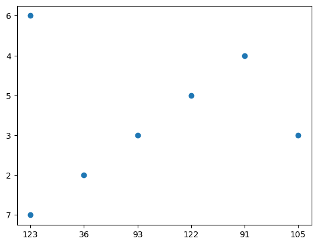

```python
plt.scatter(UMD_Year_Avg_Stats['First Downs Rushing'],UMD_Year_Avg_Stats['Wins'], label = "Team Salary")
```

Well, that doesn't look at all right. Neither axis is sorted properly, in fact it looks like it just drew each point as it went along the data frame.

The issue we're having here, is that it doesn't know how to read the data we have. While I could have fixed this issue back in the Data Cleaning area, I wanted to show how this error comes about and why it's important.

When when you and I look at the dataframe, we see values we understand, clear numbers, times, tuples of data. But what does the progam see?

We can find out with [`dtypes`](https://pandas.pydata.org/docs/reference/api/pandas.DataFrame.dtypes.html) by calling it on our dataframe, that will tell us what our types are:

```python
UMD_Year_Avg_Stats.dtypes
```

```
Statistic
Wins                                      object
Losses                                    object
Total Attendence                          object
Points Per Game PPG                       object
Total Points Scored                       object
First Downs Rushing                       object
First Downs Passing                       object
First Downs Penalty                       object
First Downs Total                         object
Rushing Yards Gained                      object
Rushing Yards Lost                        object
Rushing Attempts                          object
Rushing Average Per Attempt               object
Rushing Average Per Game                  object
Rushing Touchdowns                        object
Rushing Total: Gained - Lost              object
Passing Attempt - Complete - Intercept    object
Passing Average Per Attempt               object
Passing Average Per Game                  object
Passing Touchdowns                        object
Passing Total Distance                    object
Offense Total Plays                       object
Offense Average Per Play                  object
Offense Average Per Game                  object
Offense Total Yards                       object
Offense Touchdowns                        object
Returns Kickoff: Average                  object
Returns Kickoff: Total                    object
Returns Punt: Average                     object
Returns Punt: Total                       object
Returns INT: Average                      object
Returns INT: Total                        object
Kicking Punt: Average Yards Per Game      object
Kicking Punt: Net Average                 object
Kicking Punt: Total Yards                 object
Kicking Field Goal: Good - Attempts       object
Kicking Onside Kicks                      object
Penalties Average Yards Per Game          object
Penalties Total In Yards                  object
Time of Possession: Average               object
Time of Possession: Total                 object
Misc: 3rd Down Conversions                object
Misc: 4th Down Conversions                object
Misc: Fumbles - Lost                      object
Misc: Sacks - Yards Lost                  object
Misc: PAT: Good - Attempts                object
Misc: Yards (?)                           object
Misc: Red Zone: Attempts - Scores         object
Misc: Red Zone: Touchdown                 object
dtype: object
```

Everything was imported as an "object", which slightly complicates things. When we try to plot this data, the program has no idea how to handle an object, so it just returns a string.

If we want to graph, or analyze, or do *anything*, we're going to have to fix the types. Luckily that isn't too hard.

We're going to convert each column to a number using [`.to_numeric`](https://pandas.pydata.org/docs/reference/api/pandas.to_numeric.html). Something that will help us with that is the [`.apply`](https://pandas.pydata.org/pandas-docs/stable/reference/api/pandas.DataFrame.apply.html) function, which will apply the numeric function to each column we point at.

So now we'll convert all of the numeric columns:

```python
# Make a copy so we aren't altering our original data
UMD_Year_Avg_Stats_Graph = UMD_Year_Avg_Stats
# Change the type of each column that has numeric
UMD_Year_Avg_Stats_Graph.iloc[:,0:16] = UMD_Year_Avg_Stats_Graph.iloc[:,0:16].apply(pd.to_numeric)
UMD_Year_Avg_Stats_Graph.iloc[:,17:27] = UMD_Year_Avg_Stats_Graph.iloc[:,17:27].apply(pd.to_numeric)
UMD_Year_Avg_Stats_Graph.iloc[:,28:29] = UMD_Year_Avg_Stats_Graph.iloc[:,28:29].apply(pd.to_numeric)
UMD_Year_Avg_Stats_Graph.iloc[:,30:31] = UMD_Year_Avg_Stats_Graph.iloc[:,30:31].apply(pd.to_numeric)
UMD_Year_Avg_Stats_Graph.iloc[:,32:34] = UMD_Year_Avg_Stats_Graph.iloc[:,32:34].apply(pd.to_numeric)
UMD_Year_Avg_Stats_Graph.iloc[:,37:38] = UMD_Year_Avg_Stats_Graph.iloc[:,37:38].apply(pd.to_numeric)
```

```
UMD_Year_Avg_Stats_Graph.iloc[:,0:16] = UMD_Year_Avg_Stats_Graph.iloc[:,0:16].apply(pd.to_numeric)
```

We're using an "old method", since a future version of the code won't require us to set it equal to itself.

After that a simple:

```
UMD_Year_Avg_Stats_Graph.iloc[:,0:16].apply(pd.to_numeric)
```

Will set the values **in place** which, as we've said, will overwrite the inital data <sub>which is what we want anyways</sub>.

Nothing to worry about here.

Now that the data has been changed over to the proper data type, let's try to plot that again:

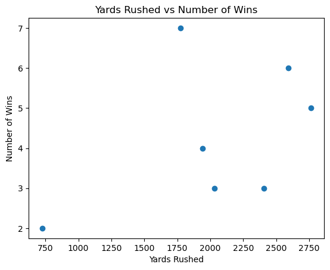

```python
plt.scatter(UMD_Year_Avg_Stats['Rushing Total: Gained - Lost'],UMD_Year_Avg_Stats['Wins'], label = "Total Rushing and Wins")
plt.xlabel("Yards Rushed")
plt.ylabel("Number of Wins")
plt.title("Yards Rushed vs Number of Wins")
plt.show()
```

Ok it's actually working now and we can see the observations we've plotted. Just looking at it gives a little bit of an idea, but it's all vague. One thing we can do with data is plot a line along the data points, and this is called a [linear regression](https://en.wikipedia.org/wiki/Linear_regression).

There are numerous libraries that can do this, for this first regression, we'll use [`SciPy`](https://scipy.org/)'s linear regression to draw this line via its [`stats.linregress`](https://docs.scipy.org/doc/scipy/reference/generated/scipy.stats.linregress.html) method.

We'll create a linear regression with the linregress method, and then take its intercept and slope values and apply them to our base "Yards Rushed" value.

This will result in a plot that shows the expected number of wins in a season based on how many total yards you rush thorugh that season.

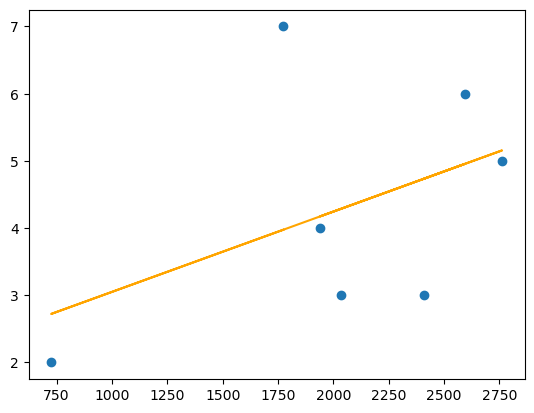

```python
# import SciPy
import scipy as sp
yards_rushed = UMD_Year_Avg_Stats['Rushing Total: Gained - Lost']
# Create the linear model:
reg = sp.stats.linregress(yards_rushed,UMD_Year_Avg_Stats['Wins'])
# Plot the scatter plot:
plt.scatter(UMD_Year_Avg_Stats['Rushing Total: Gained - Lost'],UMD_Year_Avg_Stats['Wins'], label = "Total Rushing and Wins")
# PLot the regression line:
plt.plot(yards_rushed, reg.intercept + reg.slope*yards_rushed, color = "orange", label='Linear Regression')
```

The line is the linear regression, which in simple terms is a line that has minimized the distance from each point to itself.  
These distances are called the residuals, and this line could be considered the line of best fit for our data.

There's something to notice here, you might think that this line is a bit higher than it should be, this is because we have an outlier in our data.

The point up at seven wins stands out from the rest of the data, so it's altering the linear regression of the data. This is important because it brings up two important concepts:

- Linear regression can be affected by outliers
- Small data sets can lead to less accurate models

First: if we dropping the outlier we can demonstrate how it affects the regression. Keep in mind that dropping any data will influence your data set, and so careful thought is needed before doing so.

However we won't remove the data from our souce for this example, we'll just make a copy to demonstrate:

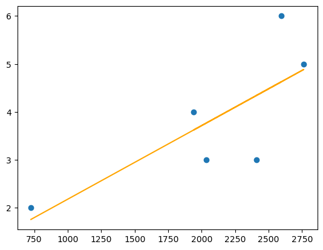

```python
# set this equal to the dataframe with 2021 dropped, this makes a copy
UMD_Year_Avg_Stats_Dropped = UMD_Year_Avg_Stats.drop(['2021'])
yards_rushed = UMD_Year_Avg_Stats_Dropped['Rushing Total: Gained - Lost']
# Create the linear model:
reg = sp.stats.linregress(yards_rushed,UMD_Year_Avg_Stats_Dropped['Wins'])
# Plot the scatter plot:
plt.scatter(UMD_Year_Avg_Stats_Dropped['Rushing Total: Gained - Lost'],UMD_Year_Avg_Stats_Dropped['Wins'], label = "Total Rushing and Wins")
# PLot the regression line:
plt.plot(yards_rushed, reg.intercept + reg.slope*yards_rushed, color = "orange", label='Linear Regression')
```

Now with the outlier dropped, we can see the linear regression line is much lower, and matches the data much more closely.

This also demonstrates our second point, a small data set is greatly influenced by changes in it, as well as by outliers in it.  
While it's true we have tables and tables of data available to us, we in fact only have 7 observations. This is a (very) small dataset as far as data science is concerned.

## Hypothesis Testing and Modeling

So what's next?

We'll we've obtained a sample of data, cleaned it, and viewed an aspect of it, next we should consider what we want to learn about this data. In statistics and data science, this has a special term: Hypothesis Testing.

At its core Hypothesis Testing has two main concepts: The Null Hypothesis and the Alternative Hypothesis.

- The Null Hypothesis could be considered the "default" belief. It's the current idea that you're challenging.
- The Alternative Hypothesis is the new idea you're proposing.

So with the data we have available, what hypothesis will I want to test?

- In what I've read online, you need to rely on both passing and rushing to win, since one isn't necessarily better than the other.

So the null hypothesis would be that this is true, and the alternative hypothesis would be that this is false.

In order to test this, we'll need to model how passing and rushing affect the win rate. We'll build a simple OLS model to test this.

**Note:** Hypothesis testing is much more complex than this simple concept I've mentioned here, and it's well worth [reading up on](https://online.stat.psu.edu/statprogram/reviews/statistical-concepts/hypothesis-testing) about it.

For our data set we can use an [Ordinary Least Squares](https://en.wikipedia.org/wiki/Ordinary_least_squares) (OLS) method of regression to build a model to figure this out.  
We can use another library [`statsmodels`](https://www.statsmodels.org/stable/index.html) in order perform this OLS rather easily. We'll be using the [`.ols`](https://www.statsmodels.org/stable/examples/notebooks/generated/ols.html#) to do this.  
Fitting an OLS with this library is rather intuitive, as it uses a formula method that is easy to understand:

formula = DEPENDENT VARIABLE ~ INDEPENDENT VARIABLE #1 * INDEPENDENT VARIABLE #2 ... * INDEPENDENT VARIABLE #N

So in this case it will be: Wins ~ Rushing Yards * Rushing Touch Downs.  
[`statsmodels`](https://www.statsmodels.org/stable/index.html) by using * as the link between dependent variables the report will list out how much that particular aspect affected the other parts of the OLS.

**Note:** statsmodels can be very picky about it's input data. If you're having trouble with getting ols to accept your values from your dataframe, then redefine them as lists like I did here.

```python
import statsmodels.formula.api as stat
win = UMD_Year_Avg_Stats['Wins'].tolist()
rushyard = UMD_Year_Avg_Stats['Rushing Yards Gained'].tolist()
rushtouch = UMD_Year_Avg_Stats['Rushing Touchdowns'].tolist()
# performing the regression
# and fitting the model
stats  = stat.ols(formula="win ~ rushyard * rushtouch", data=UMD_Year_Avg_Stats).fit()
print(stats.summary())
```

```
                            OLS Regression Results
==============================================================================
Dep. Variable:                    win   R-squared:                       0.401
Model:                            OLS   Adj. R-squared:                 -0.199
Method:                 Least Squares   F-statistic:                    0.6687
Date:                Fri, 12 May 2023   Prob (F-statistic):              0.626
Time:                        00:54:29   Log-Likelihood:                -11.713
No. Observations:                   7   AIC:                             31.43
Df Residuals:                       3   BIC:                             31.21
Df Model:                           3
Covariance Type:            nonrobust
======================================================================================
                         coef    std err          t      P>|t|      [0.025      0.975]
--------------------------------------------------------------------------------------
Intercept              2.7416      5.251      0.522      0.638     -13.969      19.453
rushyard              -0.0027      0.006     -0.457      0.679      -0.021       0.016
rushtouch              0.3242      0.430      0.754      0.506      -1.044       1.692
rushyard:rushtouch  2.827e-05      0.000      0.169      0.876      -0.001       0.001
==============================================================================
Omnibus:                          nan   Durbin-Watson:                   1.567
Prob(Omnibus):                    nan   Jarque-Bera (JB):                0.005
Skew:                           0.009   Prob(JB):                        0.997
Kurtosis:                       2.867   Cond. No.                     4.05e+05
==============================================================================

Notes:
[1] Standard Errors assume that the covariance matrix of the errors is correctly specified.
[2] The condition number is large, 4.05e+05. This might indicate that there are
strong multicollinearity or other numerical problems.
```

So when this pops up you may not know where to start, but we'll break it down step by step:  
<sub>also the error is spoiler for a future discussion</sub>

Starting from the top right:

- Dep. Variable: **Win** The dependent variable - What we're modelling for
- Model: **OLS** - What we're using, Ordinary Least Squares
- Method: **Least Squares** - Again, it's using least squares, nothing unusual here
- Date & Time: Self explanatory
- No of Observations: **7** - How many observations we've viewed
- Df Residuals : **3** - This is essentially our degrees of freedom, or Observations - Variables - 1
- Df Model: **3** - This is the number of variables we're using to predict
- Covariance Type: **nonrobust** - This can either be robust or nonrobust. What nonrobust means is that we weren't able to use the [covariance](https://en.wikipedia.org/wiki/Covariance) of our data to remove some of the variables

Now on the top left:

- R-Squared: **0.401** - This is how much our independent variables affected our dependent variable. In this case the rushing yard total and the touchdown total resulted in a 40% change in our win variable.
- Adj. R-Squared: **-0.199** - R-squared is funny, if you kept adding variables to model the data, it would only go up in value. However some of those variables may not be helpful in the analysis. This value tells us that one of our variables isn't pulling its weight in the regression.
- F-statistic: **0.6687** - This is a value you need to use with an F-table to find out if your variables are [statistically significant](https://en.wikipedia.org/wiki/Statistical_significance). We won't worry about this for now.
- Prob(F-Statistic): **0.626** - We could consider this regression to also be a hypothesis test, in that case we would say the null hypothesis is that the independent variables have no effect on the dependent variable. This is a percentage chance of the null hypothesis being right. So what this is telling us, is that there's a high probability that the wins aren't strongly affected by rushing information.
- Log-Likelihood: **-11.713** - In short, this is how well the model fits the data, higher numbers mean the model fits better.
- AIC & BIC: These are similar to Log-Likelihood as they're measuring how well the models work in linear regression. Discussing these would be a bit lengthy, so it's best to read up on [AIC](https://builtin.com/data-science/what-is-aic) and [BIC](https://www.statisticshowto.com/bayesian-information-criterion/) when you have time.

Now we can look at the middle, which usually gives the data we're looking for. Let copy the data so you don't have to keep scrolling up:

|  | coef | std err | t | P>{t} | [0.025 | 0.975] |
| --- | --- | --- | --- | --- | --- | --- |
| Intercept | 2.7416 | 5.251 | 0.522 | 0.638 | -13.969 | 19.453 |
| rushyard | -0.0027 | 0.006 | -0.457 | 0.679 | -0.021 | 0.016 |
| rushtouch | 0.3242 | 0.430 | 0.754 | 0.506 | -1.044 | 1.692 |
| rushyard:rushtouch | 2.827e-05 | 0.000 | 0.169 | 0.876 | -0.001 | 0.001 |

*Intercept* is the model as if we ran it with **no** independent variables. It's analagous to y = 0x + B, so in this case it would be our B.

*rushyard*, *rushtouch* are the independent results of each variable.

*rushyard:rushtouch* is the effect that rushyard and rushtouch had on each other.

Each of these have a column of results. From left to right we have:

- **coef**: The coefficient of each variable, or how much that variable has an effect on the result. This would be the m in y = mx + B.
- **std err**: This is the measure of [standard deviation](https://en.wikipedia.org/wiki/Standard_deviation) for the coefficient over all points of data.
- **t**: This is essentially how far the measured value is away from the expected value created by the model caused by standard error. It's used in the next part which is:
- **P > |t|** : This is similar in concept to the F-statistic. P is calculated using t, and calculates the chance that your dependent variable is **not** changed by the independent variable. It is a percentage chance of the null hypothesis being correct: that the variables had no effect.
- **[0.025 0.975]**: This is a 95% [confidence interval](https://en.wikipedia.org/wiki/Confidence_interval) of our data. This is the range of values within two [standard deviations](https://en.wikipedia.org/wiki/Standard_deviation) of our mean. In simpler terms, it means anything smaller than the 0.025 value or larger than the 0.975 value are unlikely to occur and could be considered outliers.

- **Omnibus**: A measurement of how [normal](https://en.wikipedia.org/wiki/Normal_distribution) our residuals are, with a value of 0 meaning perfectly normal. This means that the residuals shouldn't have any unusual patterns of their own. We have nan due to the small sample size.
- **Prob(Omnibus)**: This is the probability that our residuals are normally distributed.
- **Skew**: This is a measurement of how evenly distributed our data is, or how symmetrical it is.
- **Kurtosis**: The measurement of how light or heavily tailed our data is. In simple terms this is how much our data moves away from the linear regression at the ends, or how many outliers there are. Higher numbers mean a better normality.
- **Durbin-Watson**: How evenly our errors are distributed throughout our data. It's more complicated than that, so you can read up on it [here](https://en.wikipedia.org/wiki/Durbin%E2%80%93Watson_statistic).
- **Jarque-Bera (JB)**: This is similar to the Omnibus, a measurement of how normal the residuals are.
- **Prob(JB)**: This is similar to Prob(Omnibus), a percent chance on how normal the residuals are.
- **Condition No.**: Essentially this is a measurement that our independent variables are directly affecting each other and changing our results. For example if A helps B, and we're measuring A + B, then B already has A's help, and we're double counting that.

Well that was quite a bit of text. What does it *mean*?

Before that, let's run another OLS for the passing information:

```python
passyard = UMD_Year_Avg_Stats.iloc[:,20].tolist()
passtouch = UMD_Year_Avg_Stats['Passing Touchdowns'].tolist()
# performing the regression
# and fitting the model
stats  = stat.ols(formula="win ~ passyard * passtouch", data=UMD_Year_Avg_Stats).fit()
print(stats.summary())
```

```
                            OLS Regression Results
==============================================================================
Dep. Variable:                    win   R-squared:                       0.728
Model:                            OLS   Adj. R-squared:                  0.456
Method:                 Least Squares   F-statistic:                     2.678
Date:                Fri, 12 May 2023   Prob (F-statistic):              0.220
Time:                        00:54:44   Log-Likelihood:                -8.9471
No. Observations:                   7   AIC:                             25.89
Df Residuals:                       3   BIC:                             25.68
Df Model:                           3
Covariance Type:            nonrobust
======================================================================================
                         coef    std err          t      P>|t|      [0.025      0.975]
--------------------------------------------------------------------------------------
Intercept             -2.4368      5.615     -0.434      0.694     -20.306      15.433
passyard               0.0082      0.005      1.493      0.232      -0.009       0.026
passtouch             -0.5145      0.592     -0.869      0.449      -2.399       1.370
passyard:passtouch -8.497e-05      0.000     -0.696      0.536      -0.000       0.000
==============================================================================
Omnibus:                          nan   Durbin-Watson:                   1.469
Prob(Omnibus):                    nan   Jarque-Bera (JB):                0.338
Skew:                           0.275   Prob(JB):                        0.845
Kurtosis:                       2.075   Cond. No.                     5.38e+05
==============================================================================

Notes:
[1] Standard Errors assume that the covariance matrix of the errors is correctly specified.
[2] The condition number is large, 5.38e+05. This might indicate that there are
strong multicollinearity or other numerical problems.
```

Now let's look at the data and draw some conclusions:

## Interpretation & Conclusion

Let's try interpret this information and see what we can find out. First let's take a look at the F-Statistics for both models:

- Rushing: F-statistic: **0.6687**, Prob (F-statistic): **0.626**
- Passing: F-statistic: **2.678**, Prob (F-statistic): **0.220**

The F-Statistic measures how statistically significant the variables were to the model, and the Probability of it is a measurement of the chance that the variables were insignificant.

As we see, the passing model had a much *higher* statistic and a much *lower* probability that the data was insignificant. This means that, as a whole, the passing model is much more likely to be a better model of the data.

Let's also take a look at the P values for each:

- Rushing:
  - rushyard p-value: **0.679**
  - rushtouch p-value: **0.506**
- Passing:
  - passyard p-value: **0.232**
  - passtouch p-value: **0.449**

Each of the p-values show what's the percentage chance that the variable has no effect on wins. Clearly lower value means more of chance for the variable to have effect.

We can see that both of the rushing values are rather high, especially when you consider a "suitable" p-value is usually around .05. Passing is also high, but both of those values are lower than the Rushing values, meaning that in their model, they have more impact.

If you had a much better defined model, you could see how much each value affected wins by the co-efficient, as that would represent how much of a win you would obtain by rushing one yard.

#### So what's our conclusion?

Hypothesis Testing is concluded by **rejecting** the null hypothesis or **not rejecting** it. Note that not rejecting isn't *accepting* the null hypothesis, that would mean something quite different.

What **not rejecting** means is that we *don't have enough evidience yet* to disprove the null hypothesis, if you can't disprove something that doesn't mean you automatically *accept* it.

Looking at our model, we see very low F-Statistics and high Probability(F-Statistics), each p-value is WAY above what would be considered acceptable values (.05), and our coefficents are all not helpful.

This leads me to say that I **am not rejecting** the Null Hypothesis, simply due to the fact that the model lacks enough data to draw conclusions.

What I will say is that I saw a slight lean in the information that passing fits better, but that means *statistically nothing.*  
read: doesn't mean anything*

At most it's an insight for further investigation.

Always remember, if it turns out your data is inconclusive, **never** try to shoehorn it into a form that demonstrates something. The data science is still *science,* we're trying to develop experiments to learn new things.

If you alter your data so that you get a better P-value, or a high F-Statistic, then the there's almost no point to the experimen, you would be drawing conclusions from misleading data.

#### What could we do to do better?

Increase the amount of data used in the model.

As mentioned in the introduction, there are [numerous](https://www.kaggle.com/) [websites](https://data.gov/) and even a [Google Dataset Search](https://datasetsearch.research.google.com/) you can use to get pre-collected or even pre-cleaned data.

We could also get the years prior to 2015 and develop code to clean and tidy those datasets, and then re-run the code. Or we could get other collegate football team information and add that to the model.

# Recap

In this document we have:

- Obtained data from a **scraping** a website
- **Cleaned and tidied** that data to make it useful
- Seen common errors and issues when you **explore and visualize** that data.
- Used that data to make a simple **model to draw conclusions from**
- Arrived at a conclusion and **discussed what it really meant**

To be honest, this is just the tip of the iceberg and there's a [ton](https://towardsdatascience.com/gradient-descent-algorithm-a-deep-dive-cf04e8115f21) [of](https://towardsdatascience.com/understanding-k-means-clustering-in-machine-learning-6a6e67336aa1) [other](https://en.wikipedia.org/wiki/Dimensionality_reduction) [really](https://online.stat.psu.edu/stat500/lesson/11/11.2/11.2.1) [amazing](https://www.analyticsvidhya.com/blog/2021/06/understanding-random-forest/) [concepts](https://www.deeplearning.ai/resources/natural-language-processing/) [around](https://www.ibm.com/topics/neural-networks), and each one is worth learning about.

While some of higher level ideas of Data Science and Machine Learning seem really advanced or difficult, you should remember that these were built step by step with the same concepts we've learned about in this tutorial.

No matter what they're trying to reduce error and create a more accurate model, much like the OLS we did.

I hope this was a good introduction to the bare bones of data science, and that you'll proceed to learn more about what this discipline can do.

Happy computing,

Alex